# Run the cell below to generate the road map (do not modify it)

```python
%%javascript
var kernel = IPython.notebook.kernel;var thename = window.document.getElementById("notebook_name").innerHTML;var command = "THE_NOTEBOOK = " + "'"+thename+"'";kernel.execute(command);command="os.environ['THE_NOTEBOOK'] = THE_NOTEBOOK";kernel.execute(command);var cell = IPython.notebook.get_cell(2);cell.execute();IPython.notebook.get_cell(3).focus_cell();var x = $('.code_cell');$(x[1]).children('.input').hide();
```

```python
outputdir = "/tmp/tools/"
!mkdir -p $outputdir
!wget "https://www.dropbox.com/s/4g0pigmro4vo1b4/menutemplate?dl=0" -O /tmp/tools/menutemplate >> /tmp/toollog 2>&1
!wget "https://www.dropbox.com/s/3flttpzhsja8td7/construct_menu.py?dl=0" -O /tmp/tools/construct_menu.py >> /tmp/toollog 2>&1
!python /tmp/tools/construct_menu.py "{THE_NOTEBOOK}.ipynb" {outputdir}
from IPython.core.display import HTML
output_file_name = outputdir + THE_NOTEBOOK.replace(" ", "").replace("[", "").replace("]", "") + ".ipynb.html"
with open(output_file_name) as fp:
    html = fp.read()
HTML(html)
```

- ROADMAP

  - Estimating Financial Risk through Monte Carlo Simulation

    - Goals

    - Steps

    - Reference

  - 1. Introduction

    - 1.1. Monte Carlo Simulation (MCS)

    - 1.2. How does it work?

  - 2. Illustrative example

    - 2.1. Unit sales and unit price

      - Question 1

    - 2.2. Unit Cost

    - 2.3. A Flawed Model: using averages to represent our random variables

      - Question 2

        - Question 2.1

        - Question 2.2

    - 2.4. Using the Monte Carlo Simulation method to improve our model

      - Question 3

        - Question 3.1

        - Question 3.2

  - 3. A brief summary of the Monte Carlo Simulation (MCS) technique

  - 4. Common distributions used in MCS

  - 5. A real use case: estimating the financial risk of a portfolio of stocks

    - 5.1. Terminology

    - 5.2. The context of our use case

    - 5.3. The Data

    - 5.4. Data preprocessing

      - Factor data pre-processing

      - Question 4

        - Question 4.1

        - Question 4.2

      - Stock data pre-processing

        - Question 4.3

      - Time alignment for our data

        - Question 4.4

      - Dealing with missing values

        - Question 4.5

        - Question 4.6

    - 5.5. Summary guidelines to apply the MCS method on the data we prepared

    - 5.6. Applying MCS

      - Step 1: Defining relationship between market factors and instrument's returns

      - Question 5

        - Question 5.1

        - Question 5.2

        - Question 5.3

      - Step 2: Defining the distributions for the market conditions

      - Question 6

        - Question 6.1

        - Question 6.2

      - Step 3&4: Generating samples, running simulation and calculating the VaR

      - Question 7

      - Step 5: Evaluating the results using backtesting method

      - Question 8

        - Question 8.1

        - Question 8.2

        - Question 8.3

      - Question 9

      - Question 10

  - 6. Summary

  - References

    - Optimisation of the linear model:

    - Optimisation of the distribution models:

- QUESTIONS

  - Question 1

  - Question 2

    - Question 2.1

    - Question 2.2

  - Question 3

    - Question 3.1

    - Question 3.2

  - Question 4

    - Question 4.1

    - Question 4.2

    - Question 4.3

    - Question 4.4

    - Question 4.5

    - Question 4.6

  - Question 5

    - Question 5.1

    - Question 5.2

    - Question 5.3

  - Question 6

    - Question 6.1

    - Question 6.2

  - Question 7

  - Question 8

    - Question 8.1

    - Question 8.2

    - Question 8.3

  - Question 9

  - Question 10

```python
#### cell for gabriel
import os
import sys

# Path for spark source folder
os.environ['SPARK_HOME']="C:\spark-1.6.1-bin-hadoop2.6"

# Append pyspark  to Python Path
sys.path.append("C:\spark-1.6.1-bin-hadoop2.6\python")
sys.path.append("C:\spark-1.6.1-bin-hadoop2.6\python\lib\py4j-0.9-src.zip")
#os.environ['SPARK_EXECUTOR_MEMORY']="5G"

try:
    from pyspark import SparkContext
    from pyspark import SparkConf
    print ("Successfully imported Spark Modules")

except ImportError as e:
    print ("Can not import Spark Modules", e)
    sys.exit(1)

# Initialize SparkContext
sc = SparkContext('local')
words = sc.parallelize(["scala","java","hadoop","spark","akka"])
print (words.count())
```

```
Successfully imported Spark Modules
5
```

```python
# imports
import numpy as np
import random
import time
import matplotlib.pyplot as plt
import matplotlib.patches as mpatches
%matplotlib inline
from datetime import datetime
from datetime import timedelta
from itertools import islice
import statsmodels.api as sm
from os import listdir
from os.path import isfile, join
from statsmodels.nonparametric.kernel_density import KDEMultivariate
from statsmodels.nonparametric.kde import KDEUnivariate
import matplotlib.pyplot as plt
import scipy
from scipy import stats
import math
import statistics
import itertools

#font for plots
font = {'family': 'sans-serif',
        'color':  'darkred',
        'weight': 'normal',
        'size': 16,
        }
```

# Estimating Financial Risk through Monte Carlo Simulation

Risk analysis is part of every decision we make when faced with uncertainty, ambiguity, and variability. Indeed, even though we have unprecedented access to information, we can't accurately predict the future. In finance, there is a fair amount of uncertainty and risk involved with estimating the future value of financial products, due to the wide variety of potential outcomes. Monte Carlo simulation (also known as the Monte Carlo Method) allows inspecting many possible outcomes of the decision making process, and can be used to assess the impact of risk: this, in turns, allows for better decision making under uncertainty.

## Goals

The main objectives we set for this Notebook are as follows:

1. Develop fudamental knowledge about Risk analysis
2. Understand Monte Carlo Simulation (MCS)
3. Apply Monte Carlo Simulation for predicting risk

## Steps

1. First, in section 1, we introduce the basics of MCS
2. In section 2, we work on a simple example to where we apply the MCS method
3. In section 3, we briefly summarize the main characteristics of the Monte Carlo Simulation (MCS) technique
4. In section 4, we overview the common distributions which are often used in MCS
5. In section 5, we work on a real use case, that focuses on estimating financial risk. We will use techniques such as featurizing (that is, generating additional features to improve model accuracy), linear regression, kernel density estimation, sampling distributions and so on ...

## Reference

This Notebook is inspired by Chapter 9 of the book [Advanced Analytics with Spark](http://shop.oreilly.com/product/0636920035091.do) by Josh Wills, Sandy Ryza, Sean Owen, and Uri Laserson. It is strongly suggested to read this Chapter to get a general idea of the topic of this Notebook.

# 1. Introduction

## 1.1. Monte Carlo Simulation (MCS)

Monte Carlo simulation is a computerized mathematical technique that can be applied such that it is possible to account for risk in quantitative analysis and decision making. This technique is used in many different fields, such as R&D, risk management, portfolio management, pricing derivatives, strategic planning, project planning, cost modeling and many more.

In general, MCS is a technique that "converts" uncertainty on input variables of a model into **probability distributions**. By combining the distributions and randomly selecting values from them, it recalculates the simulated model many times, to determine the probability of the output.

Historically, this technique was first used by scientists working on the atomic bomb: it was named after Monte Carlo, the Monaco resort town renowned for its casinos. Since its introduction in World War II, Monte Carlo simulation has been used to model a variety of physical and conceptual systems.

## 1.2. How does it work?

Monte Carlo simulation performs risk analysis by building models of possible results by *substituting a range of possible input values, that constitute uncertainty, into a statistical distribution*. It then computes possible outcomes repeatedly, each time using a different set of random values from the probability functions that "model" the input. Depending upon the number of random input variables and their distribution, a Monte Carlo simulation could involve thousands or tens of thousands of "rounds" before it is complete. When complete, *Monte Carlo simulation produces distributions of possible outcome values*.

By using probability distributions instead of actual input samples, it is possible to model more accurately uncertainty: different choices of distributions will yield different outputs.

# 2. Illustrative example

Imagine you are the marketing manager for a firm that is planning to introduce a new product. You need to estimate the first year net profit from this product, which might depend on:

- Sales volume in units
- Price per unit (also called "Selling price")
- Unit cost
- Fixed costs

Net profit will be calculated as $Net Profit = Sales Volume* (Selling Price - Unit cost) - Fixed costs$. Fixed costs (accounting for various overheads, advertising budget, etc.) are known to be \$ 120,000, which we assume to be deterministic. All other factors, instead, involve some uncertainty: *sales volume* (in units) can cover quite a large range, the *selling price* per unit will depend on competitor actions, which are hard to predict, and *unit costs* will also vary depending on vendor prices and production experience, for example.

Now, to build a risk analysis model, we must first identify the uncertain variables -- which are essentially random variables. While there's some uncertainty in almost all variables in a business model, we want to focus on variables where the range of values is significant.

## 2.1. Unit sales and unit price

Based on an hypothetical market research you have done, you have beliefs that there are equal chances for the market to be `slow`, `normal`, or `hot`:

- In a "slow" market, you expect to sell 50,000 units at an average selling price of \$11.00 per unit
- In a "normal" market, you expect to sell 75,000 units, but you'll likely realize a lower average selling price of \$10.00 per unit
- In a "hot" market, you expect to sell 100,000 units, but this will bring in competitors, who will drive down the average selling price to \$8.00 per unit

[figure not shown]

### Question 1

Calculate the average units and the unit price that you expect to sell, which depend on the market state. Use the assumptions above to compute the expected quantity of products and their expected unit price.

```
average_unit = ...
average_price = ...
print("average unit:", average_unit)
print("average_price:", average_price)
```

```python
import numpy as np

units = np.array([50000, 75000, 100000])
prices = np.array([11.0, 10.0, 8.0])
average_unit = np.mean(units)
#average_price = np.sum(units*prices)/(np.sum(units))
average_price = np.sum(prices)/3
print("average unit:", average_unit)
print("average_price:", average_price)
```

```
average unit: 75000.0
average_price: 9.66666666667
```

## 2.2. Unit Cost

Another uncertain variable is Unit Cost. In our illustrative example, we assume that your firm's production manager advises you that unit costs may be anywhere from \$5.50 to \$7.50, with a most likely expected cost of \$6.50. In this case, the most likely cost can be considered as the average cost.

## 2.3. A Flawed Model: using averages to represent our random variables

Our next step is to identify uncertain functions -- also called functions of a random variable. Recall that Net Profit is calculated as $Net Profit = Sales Volume * (Selling Price - Unit cost) - Fixed costs$. However, Sales Volume, Selling Price and Unit Cost are all uncertain variables, so Net Profit is an uncertain function.

The most simple model to predict the Net Profit is using average of sales volume, average of selling price and average of unit cost for calculating. So, if only consider averages, we can say that the $Net Profit = 75,000*(9.66666666 - 6.5) - 120,000 \sim 117,500$.

However, as [Dr. Sam Savage](http://web.stanford.edu/~savage/faculty/savage/) warns, "Plans based on average assumptions will be wrong on average." The calculated result is far from the actual value: indeed, the **true average Net Profit** is roughly \$93,000, as we will see later in the example.

[figure not shown]

### Question 2

#### Question 2.1

Write a function named `calNetProfit` to calculate the Net Profit using the average of sales volume, the average of selling price and the average of unit cost.

```
def calNetProfit(average_unit, average_price, average_unitcost, fixed_cost):
    return ...

average_unitcost = ...
fixed_cost = ...
NetProfit = calNetProfit(...,...,...,...)
print("Net profit:", NetProfit)
```

```python
def calNetProfit(average_unit, average_price, average_unitcost, fixed_cost):
    return average_unit*(average_price-average_unitcost)-fixed_cost

average_unitcost = 6.50
fixed_cost = 120000
NetProfit = calNetProfit(average_unit,average_price,average_unitcost,fixed_cost)
print("Net profit:", NetProfit)
```

```
Net profit: 117500.0
```

#### Question 2.2

Verify the warning message of Dr. Sam Savage by calculating the error of our estimated Net Profit using averages only. Recall that the true value is roughly \$93,000, so we are interested in:

$$ error = \frac{your\_value - true\_value}{true\_value}$$

Note also we are interested in displaying the error as a percentage.

Looking at the error we make, do you think that we can use the current model that only relies on averages?

```
trueNetProfit = ...
error = (... - ...) / (...)
print("Error in percentage:", error * ...)
```

```python
trueNetProfit = 93000
error = (NetProfit - trueNetProfit) / (trueNetProfit)
print("Error in percentage:", abs(error * 100))
```

```
Error in percentage: 26.3440860215
```

A 26 percent error is quite large. It shows that we cannot afford not make this kind of "approximation".  
If A, B, C and D are random variables and $A = f(B,C,D)$, then we cannot say $a(A)=f(a(b),a(c),a(d))$. Here a(x) is the average of x. This approximation is very bad for decision making, we cannot rely on this method for critical decisions.

## 2.4. Using the Monte Carlo Simulation method to improve our model

As discussed before, the selling price and selling volume both depend on the state of the market scenario (slow/normal/hot). So, the net profit is the result of two random variables: `market scenario` (which in turn determines `sales volumes` and `selling price`) and `unit cost`.

Now, let's assume (this is an *a-priori* assumption we make) that `market scenario` follows a discrete, uniform distribution and that `unit cost` also follows a uniform distribution. Then, we can compute directly the values for selling price and selling volumes based on the outcome of the random variable `market scenario`, as shown in Section 2.1.

From these a-priori distributions, in each run (or trial) of our Monte Carlo simulation, we can generate the sample value for each random variable and use it to calculate the Net Profit. The more simulation runs, the more accurate our results will be. For example, if we run the silmulation 100,000 times, the average net profit will amount to roughly \$92,600. Every time we run the simulation, a different prediction will be output: the average of such predictions will consistently be less than \$117,500, which we predicted using averages only.

Note also that in this simple example, we generate values for the `market scenario` and `unit cost` independently: we consider them to be **independent random variables**. This means that the eventual (and realistic!) correlation between the `market scenario` and `unit cost` variables is ignored. Later, we will learn how to be more precise and account for dependency between random variables.

[figure not shown]

### Question 3

#### Question 3.1

Write a function named `get_sales_volume_price` that returns the sales volume and price based on the market scenario. In particular, the scenario can get one of three values:

- 0: Slow market
- 1: Normal market
- 2: Hot market

The return value is a tuple in the form: `(sales_volume, price)`

```
# Get sales volume and  price based on market scenario
# the function returns a tuple of (sales_volume, price)
def get_sales_volume_price(scenario):
    # Slow market
    if scenario == 0:
        return (...,...)
    # Normal market
    if ...
    # Hot market
    if ...
```

```python
# Get sales volume and  price based on market scenario
# the function returns a tuple of (sales_volume, price)
def get_sales_volume_price(scenario):
    # Slow market
    if scenario == 0:
        return (50000,11)
    # Normal market
    if scenario == 1:
        return (75000,10)
    # Hot market
    if scenario == 2:
        return (100000,8)
```

#### Question 3.2

Run 100,000 Monte Carlo simulations and calculate the average net profit they produce. Then, compare the result to the "average model" we used in the previous questions (the one we called "flawed" model). Put your comments about the discrepancies between a simplistic model, and the more accurate MCS approach.

Note that in each iteration, the `unit_cost` and `market_scenario` are generated according to their distributions. Also, recall what we have seen in Section 2.2: your firm account manager helped you with some research, to determine the variability of your random variables.

HINT: Funtion `uniform(a,b)` in module `random` generates a number $a<=c<=b$, which is drawn from a uniform distribution. Function `randint(a,b)` helps you generating an integer number $a<=c<=b$

```
import random

total = 0.0
num_simulation = 100000
for i in range(0,num_simulation):
    unit_cost = ...
    market_scenario = ...
    sales_volume, price = get_sales_volume_price(...)
    netProfit = ...
    total = ...

print("average net profit:", ...)
```

```python
import random

fixed_cost = 120000

total = 0.0
num_simulation = 100000
for i in range(0,num_simulation):
    unit_cost = np.random.uniform(5.5, 7.5)
    market_scenario = np.random.randint(0,3)
    sales_volume, price = get_sales_volume_price(market_scenario)
    netProfit = sales_volume*(price-unit_cost)-fixed_cost
    total += netProfit

print("average net profit:", total/num_simulation)
```

```
average net profit: 92451.88848786808
```

```python
trueNetProfit = 93000
error = (total/num_simulation - trueNetProfit) / (trueNetProfit)
print("Error in percentage:", abs(error * 100))
```

```
Error in percentage: 0.5893672173461465
```

As we run a lot of simulations, we get closer to the real value. The accuracy is way better than to use the average of each random variable. It can be interesting to see how much closer we can get my throwing more simulations:

```python
# Here is a function to give an idea of where we are in the computation:
def update(current, end, startTime):
    if current==0:
        pass
    elif current == end:
        print("done")
    else:
        numSampleLeft = end - current
        timeBySample = (time.time() - startTime)/current
        secondsRemaining = int(timeBySample*numSampleLeft)
        m, s = divmod(secondsRemaining, 60)
        updateStr = "progression: " + str(int(current*100/end)) + "%  -  Estimated remaining time: "
        updateStr += str(s) + " seconds and " + str(m) + " minutes"
        print(updateStr, end="\r")
```

```python
import time
total = 0.0
num_simulation = 1000000
t = time.time()
for i in range(0, num_simulation):
    update(i, num_simulation, t)
    unit_cost = np.random.uniform(5.5, 7.5)
    market_scenario = np.random.randint(0, 3)
    sales_volume, price = get_sales_volume_price(market_scenario)
    netProfit = sales_volume*(price-unit_cost)-fixed_cost
    total += netProfit

print("average net profit:", total/num_simulation)
```

[output not shown]

```python
trueNetProfit = 93000
error = (total/num_simulation - trueNetProfit) / (trueNetProfit)
print("Error in percentage:", abs(error * 100))
```

```
Error in percentage: 0.19855170731960986
```

It's better, even if it's not very close to 0. But the good side is that the computation time is linear and that this algorithm can be easily parrallelized.

# 3. A brief summary of the Monte Carlo Simulation (MCS) technique

- A MCS allows several inputs to be used at the same time to compute the probability distribution of one or more outputs
- Different types of probability distributions can be assigned to the inputs of the model, depending on any *a-priori* information that is available. When the distribution is completely unknown, a common technique is to use a distribution computed by finding the best fit to the data you have
- The MCS method is also called a **stochastic method** because it uses random variables. Note also that the general assumption is for input random variables to be independent from eachother. When this is not the case, there are techniques to account for correlation between random variables.
- A MCS generates the output as a range instead of a fixed value and shows how likely the output value is to occur in that range. In other words, the model outputs a probability distribution.

# 4. Common distributions used in MCS

In what follows, we summarize the most common probability distributions that are used as *a-priori* distributions for input random variables:

- *Normal/Gaussian Distribution*: this is a continuous distribution applied in situations where the mean and the standard deviation of a given input variable are given, and the mean represents the most probable value of the variable. In other words, values "near" the mean are most likely to occur. This is symmetric distribution, and it is not bounded in its co-domain. It is very often used to describe natural phenomena, such as people’s heights, inflation rates, energy prices, and so on and so forth. An illustration of a normal distribution is given below:

[figure not shown]

- *Lognormal Distribution* : this is a distribution which is appropriate for variables taking values in the range $[0, \infty]$. Values are positively skewed, not symmetric like a normal distribution. Examples of variables described by a lognormal distributions include, for example, real estate property values, stock prices, and oil reserves. An illustration of a lognormal distribution is given below:

[figure not shown]

- *Triangular Distribution* : this is a continuous distribution with fixed minimum and maximum values. It is bounded by the minimum and maximum values and can be either symmetrical (the most probable value = mean = median) or asymmetrical. Values around the most likely value (e.g. the mean) are more likely to occur. Variables that could be described by a triangular distribution include, for example, past sales history per unit of time and inventory levels. An illustration of a triangular distribution is given below:

[figure not shown]

- *Uniform Distribution* : this is a continuous distribution bounded by known minimum and maximum values. In contrast to the triangular distribution, the likelihood of occurrence of the values between the minimum and maximum is the same. In other words, all values have an equal chance of occurring, and the distribution is simply characterized by the minimum and maximum values. Examples of variables that can be described by a uniform distribution include manufacturing costs or future sales revenues for a new product. An illustration of the uniform distribution is given below:

[figure not shown]

- *Exponential Distribution* : this is a continuous distribution used to model the time that pass between independent occurrences, provided that the rate of occurrences is known. An example of the exponential distribution is given below:

[figure not shown]

- *Discrete Distribution* : for this kind of distribution, the "user" defines specific values that may occur and the likelihood of each of them. An example might be the results of a lawsuit: 20% chance of positive verdict, 30% change of negative verdict, 40% chance of settlement, and 10% chance of mistrial.

# 5. A real use case: estimating the financial risk of a portfolio of stocks

We hope that by now you have a good understanding about Monte Carlo simulation. Next, we apply this method to a real use case: *financial risk estimation*.

Imagine that you are an investor on the stock market. You plan to buy some stocks and you want to estimate the maximum loss you could incur after two weeks of investing. This is the quantity that the financial statistic "Value at Risk" (VaR) seeks to measure. [VaR](https://en.wikipedia.org/wiki/Value_at_risk) is defined as a measure of investment risk that can be used as a reasonable estimate of the maximum probable loss for a value of an investment portfolio, over a particular time period. A VaR statistic depends on three parameters: a portfolio, a time period, and a confidence level. A VaR of 1 million dollars with a 95% confidence level over two weeks, indicates the belief that the portfolio stands only a 5% chance of losing more than 1 million dollars over two weeks. VaR has seen widespread use across financial services organizations. This statistic plays a vital role in determining how much cash investors must hold to meet the credit ratings that they seek. In addition, it is also used to understand the risk characteristics of large portfolios: it is a good idea to compute the VaR before executing trades, such that it can help take informed decisions about investments.

Our goal is calculating VaR of two weeks interval with 95% confidence level and the associated [VaR confidence interval](http://www.investopedia.com/ask/answers/041615/whats-difference-between-confidence-level-and-confidence-interval-value-risk-var.asp).

## 5.1. Terminology

In this use case, we will use some terms that might require a proper definition, given the domain. This is what we call the *Domain Knowledge*.

- **Instrument**: A tradable asset, such as a bond, loan, option, or stock investment. At any particular time, an instrument is considered to have a value, which is the price for which it can be sold. In the use case of this notebook, instruments are stock investments.
- **Portfolio**: A collection of instruments owned by a financial institution.
- **Return**: The change in an instrument or portfolio’s value over a time period.
- **Loss**: A negative return.
- **Index**: An imaginary portfolio of instruments. For example, the NASDAQ Composite index includes about 3,000 stocks and similar instruments for major US and international companies.
- **Market factor**: A value that can be used as an indicator of macro aspects of the financial climate at a particular time. For example, the value of an index, the Gross Domestic Product of the United States, or the exchange rate between the dollar and the euro. We will often refer to market factors as just factors.

## 5.2. The context of our use case

We have a list of instruments that we plan to invest in. The historial data of each instrument has been collected for you. For simplicity, assume that the returns of instruments at a given time, depend on 4 market factors only:

- GSPC value
- IXIC value
- The return of crude oil
- The return of treasury bonds

Our goal is building a model to predict the loss after two weeks time interval with confidence level set to 95%.

As a side note, it is important to realize that the approach presented in this Notebook is a simplified version of what would happen in a real Financial firm. For example, the returns of instruments at a given time often depend on more than 4 market factors only! Moreovoer, the choice of what constitute an appropriate market factor is an art!

## 5.3. The Data

The stock data can be downloaded (or scraped) from Yahoo! by making a series of REST calls. The data includes multiple files. Each file contains the historical information of each instrument that we want to invest in. The data is in the following format (with some samples):

```
Date, Open, High, Low, Close, Volume, Adj Close
2016-01-22,66.239998,68.07,65.449997,67.860001,137400,67.860001
2016-01-21,65.410004,66.18,64.459999,65.050003,148000,65.050003
2016-01-20,64.279999,66.32,62.77,65.389999,141300,65.389999
2016-01-19,67.720001,67.989998,64.720001,65.379997,178400,65.379997
```

The data of GSPC and IXIC values (our two first market factors) are also available on Yahoo! and use the very same format.

The crude oil and treasure bonds data is collected from investing.com, and has a different format, as shown below (with some samples):

```
Date    Price   Open    High    Low     Vol.    Change %
Jan 25, 2016    32.17   32.36   32.44   32.10   -       -0.59%
Jan 24, 2016    32.37   32.10   32.62   31.99   -       0.54%
Jan 22, 2016    32.19   29.84   32.35   29.53   -       9.01%
Jan 21, 2016    29.53   28.35   30.25   27.87   694.04K 11.22%
Jan 20, 2016    26.55   28.33   28.58   26.19   32.11K  -6.71%
Jan 19, 2016    28.46   29.20   30.21   28.21   188.03K -5.21%
```

In our use case, the factors' data will be used jointly to build a statiscal model: as a consequence, we first need to preprocess the data to proceed.

## 5.4. Data preprocessing

In this Notebook, all data files have been downloaded for you, such that you can focus on pre-processing. Next, we will:

- Read the factor data files which are in two different formats, process and merge them together
- Read the stock data and pre-process it
- Trim all data into a specific time region
- Fill in the missing values
- Generate the data of returns in each two weeks time interval window

### Factor data pre-processing

We need two functions to read and parse data from Yahoo! and Investing.com respectively. We are interested only in information about the time and the corresponding returns of a factor or an instrument: as a consequence, we will project away many columns of our RAW data, and keep only the information we are interested in.

The 3000-instrument and the 4-factor history are small enough to be read and processed locally: we do not need to use the power of parallel computing to proceed. Note that this is true also for larger cases with hundreds of thousands of instruments and thousands of factors. The need for a distributed system like Spark comes in when actually **running** the Monte Carlo simulations, which can require massive amounts of computation on each instrument.

[figure not shown]

### Question 4

#### Question 4.1

Write a function named `readInvestingDotComHistory` to parse data from investing.com based on the format specified above (see Section 5.3). Recall that we use two factors here: one that is related to the price of crude oil, one that is related to some specific US bonds.

Print the first 5 entries of the first factor (crude oil price) in the parsed data.

Note that we are only interested in the date and price of stocks.

HINT: You can parse a string to `datetime` object by using the function `strptime(<string>, <dtime_format>)`. In this case, the datetime format is `"%b %d, %Y"`. For more information, please follow this [link](https://docs.python.org/2/library/datetime.html#strftime-and-strptime-behavior).

In the next cell, we simply copy data from our HDFS cluster (that contains everything we need for this Notebook) to the instance (a Docker container) running your Notebook. This means that you will have "local" data that you can process without using Spark. Note the folder location: find and verify that you have correctly downloaded the files!

```python
! [ -d monte-carlo-risk ] || (echo "Downloading prepared data from HDFS. Please wait..." ; hdfs dfs -copyToLocal /datasets/monte-carlo-risk . ; echo "Done!";)
```

```
Downloading prepared data from HDFS. Please wait...
Done!
```

```
from datetime import datetime
from datetime import timedelta
from itertools import islice
%matplotlib inline
import numpy as np
import statsmodels.api as sm

base_folder = "monte-carlo-risk/"

factors_folder= base_folder + "factors/"

# read data from local disk
def readInvestingDotComHistory(fname):
    def process_line(line):
        cols = line.split(...)
        date = datetime.strptime(..., ...)
        value = float(...)
        return (date, value)

    with open(fname) as f:
        content_w_header = f.readlines()
        # remove the first line
        # and reverse lines to sort the data by date, in ascending order
        content = content_w_header....
        return list(map(process_line , content))

factor1_files = ['crudeoil.tsv', 'us30yeartreasurybonds.tsv']
factor1_files = map(lambda fn: factors_folder + fn, factor1_files)
factors1 = [readInvestingDotComHistory(f) for f in factor1_files]

print(factors1...)
```

```python
from datetime import datetime
from datetime import timedelta
from itertools import islice
%matplotlib inline
import numpy as np
import statsmodels.api as sm

base_folder = "monte-carlo-risk/"
# base_folder = "/Users/quentinleroy/Documents/Eurecom/AML/Lab7+8/monte-carlo-risk/"

factors_folder= base_folder + "factors/"

# read data from local disk
def readInvestingDotComHistory(fname):
    def process_line(line):
        cols = line.split("\t")
        date = datetime.strptime(cols[0], "%b %d, %Y")
        value = float(cols[1])
        return (date, value)

    with open(fname) as f:
        content_w_header = f.readlines()
        # remove the first line
        # and reverse lines to sort the data by date, in ascending order
        content = content_w_header[:0:-1]
        return list(map(process_line , content))

factor1_files = ['crudeoil.tsv', 'us30yeartreasurybonds.tsv']
factor1_files = map(lambda fn: factors_folder + fn, factor1_files)
factors1 = [readInvestingDotComHistory(f) for f in factor1_files]

print(factors1[0][:5])
```

```
[(datetime.datetime(2006, 1, 26, 0, 0), 66.26), (datetime.datetime(2006, 1, 27, 0, 0), 67.76), (datetime.datetime(2006, 1, 30, 0, 0), 68.35), (datetime.datetime(2006, 1, 31, 0, 0), 67.92), (datetime.datetime(2006, 2, 1, 0, 0), 66.56)]
```

Now, the data structure `factors1` is a list, containing data that pertains to two (out of a total of four) factors that influence the market, as obtained by investing.com. Each element in the list is a tuple, containing some sort of timestamp, and the value of one of the two factors discussed above. From now on, we call these elements "**records**" or "**entries**". Visually, `factors1` looks like this:

| 0 (crude oil) | 1 (US bonds) |
| --- | --- |
| time_stamp, value | time_stamp, value |
| ... | ... |
| time_stamp, value | time_stamp, value |
| ... | ... |

#### Question 4.2

Write a function named `readYahooHistory` to parse data from yahoo.com based on its format, as described in Section 5.3.

Print the first 5 entries of the first factor (namely GSPC). Comment the time range of the second batch of data we use in our Notebook.

Note that we are only interested in the date and price of stocks.

NOTE: The datetime format now is in a different format than the previous one.

HINT: Use a terminal (or put the bash commands inline in your Notebook) to list filenames in your local working directory to find and have a look at your local files.

```
# read data from local disk
def readYahooHistory(fname):
    def process_line(line):
        ...
        ...
        ...
        ...

    with open(fname) as f:
        ...
        ...
        ...
        ...


factor2_files = [..., ...]
factor2_files = map(lambda fn: factors_folder + fn, factor2_files)

factors2 = [readYahooHistory(f) for f in factor2_files]

print(factors2[0][:5])
```

```python
# read data from local disk
def readYahooHistory(fname):
    def process_line(line):
        cols = line.split(",")
        date = datetime.strptime(cols[0], "%Y-%m-%d")
        value = float(cols[1])
        return (date, value)

    with open(fname) as f:
        content_w_header = f.readlines()
        # remove the first line
        # and reverse lines to sort the data by date, in ascending order
        content = content_w_header[:0:-1]
        return list(map(process_line , content))


factor2_files = ['GSPC.csv','IXIC.csv']
factor2_files = map(lambda fn: factors_folder + fn, factor2_files)

factors2 = [readYahooHistory(f) for f in factor2_files]

print(factors2[0][:5])
```

```
[(datetime.datetime(1950, 1, 3, 0, 0), 16.66), (datetime.datetime(1950, 1, 4, 0, 0), 16.85), (datetime.datetime(1950, 1, 5, 0, 0), 16.93), (datetime.datetime(1950, 1, 6, 0, 0), 16.98), (datetime.datetime(1950, 1, 9, 0, 0), 17.08)]
```

We can see that there is no stock price here for the 7th and 8th of january. Let's confirm this with the piece of code below.

```python
datetime(1950, 1, 7).weekday(), datetime(1950, 1, 8).weekday()
```

```
(5, 6)
```

Now, the data structure `factors2` is again list, containing data that pertains to the next two (out of a total of four) factors that influence the market, as obtained by Yahoo!. Each element in the list is a tuple, containing some sort of timestamp, and the value of one of the two factors discussed above. Visually, `factors2` looks like this:

| 0 (GSPC) | 1 (IXIC) |
| --- | --- |
| time_stamp, value | time_stamp, value |
| ... | ... |
| time_stamp, value | time_stamp, value |
| ... | ... |

### Stock data pre-processing

Next, we prepare the data for the instruments we consider in this Notebook (i.e., the stocks we want to invest in).

#### Question 4.3

In this Notebook, we assume that we want to invest on the first 35 stocks out of the total 3000 stocks present in our datasets.

Load and prepare all the data for the considered instruments (the first 35 stocks) which have historical information for more than 5 years. This means that all instruments with less than 5 years of history should be removed.

**[HINT]**: we suggest to open a terminal window (not on your local machine, but the Notebook terminal that you can find on the Jupyter dashboard) and visually check the contents of the directories holding our dataset, if you didn't do this before! Have a look at how stock data is organized!

```
from os import listdir
from os.path import isfile, join

stock_folder = base_folder + 'stocks'

def process_stock_file(fname):
    try:
        return ...
    except Exception as e:
        raise e
        return None



# select path of all stock data files in "stock_folder"
files = [join(stock_folder, f) for f in listdir(stock_folder) if isfile(join(stock_folder, f))]

# assume that we invest only the first 35 stocks (for faster computation)
files = files[:35]

# read each line in each file, convert it into the format: (date, value)
rawStocks = [... for f in files]

# select only instruments which have more than 5 years of history
# Note: the number of business days in a year is 260
number_of_years = 5
rawStocks = list(filter(lambda instrument: ...  , rawStocks))

# For testing, print the first 5 entry of the first stock
print(rawStocks[0][:5])
```

```python
from os import listdir
from os.path import isfile, join

stock_folder = base_folder + 'stocks'

def process_stock_file(fname):
    try:
        return readYahooHistory(fname)
    except Exception as e:
        raise e
        return None



# select path of all stock data files in "stock_folder"
files = [join(stock_folder, f) for f in listdir(stock_folder) if isfile(join(stock_folder, f))]

# assume that we invest only the first 35 stocks (for faster computation)
files = files[:35]

# This line is here so that we have the same files and results on the cluster and on laptops.
baseFiles = ['AAL.csv','AAME.csv','AAOI.csv','AAON.csv','AAPL.csv','AAVL.csv','AAWW.csv','AAXJ.csv','ABAC.csv',
 'ABAX.csv','ABCB.csv','ABCD.csv','ABCO.csv','ABCW.csv','ABDC.csv','ABGB.csv','ABIO.csv', #' ABMD(2).csv',
             'ABMD.csv',
 'ABTL.csv','ABY.csv','ACAD.csv','ACAS.csv','ACAT.csv','ACET.csv','ACFC.csv','ACFN.csv','ACGL.csv','ACHC.csv',
 'ACHN.csv','ACIW.csv','ACLS.csv','ACNB.csv','ACOR.csv','ACPW.csv'
            ,'ACRX.csv' # I add the next file ACRX.csv because ABMD(2).csv is not actually a file
            ]
files = [join(stock_folder,f) for f in baseFiles]


# read each line in each file, convert it into the format: (date, value)
rawStocks = [process_stock_file(f) for f in files]

# select only instruments which have more than 5 years of history
# Note: the number of business days in a year is 260
number_of_years = 5
rawStocks = list(filter(lambda instrument: len(instrument)>=260*number_of_years , rawStocks))

# For testing, print the first 5 entry of the first stock
print(rawStocks[0][:5])
```

```
[(datetime.datetime(2005, 9, 27, 0, 0), 21.049999), (datetime.datetime(2005, 9, 28, 0, 0), 19.299999), (datetime.datetime(2005, 9, 29, 0, 0), 20.4), (datetime.datetime(2005, 9, 30, 0, 0), 20.26), (datetime.datetime(2005, 10, 3, 0, 0), 20.9)]
```

How many stocks do we have now?

```python
len(rawStocks)
```

```
28
```

Out of the first 35 files 7 doest not provide more than 5 years of data

### Time alignment for our data

Different types of instruments may trade on different days, or the data may have missing values for other reasons, so it is important to make sure that our different histories align. First, we need to trim all of our time series to the same region in time. Then, we need to fill in missing values. To deal with time series that have missing values at the start and end dates in the time region, we simply fill in those dates with nearby values in the time region.

#### Question 4.4

Assume that we only focus on the data from 23/01/2009 to 23/01/2014. Write a function named `trimToRegion` to select only the records in that time interval.

Requirements: after processing, each instrument $i$ has a list of records: $[r_0, r_2,...,r_{m_i}]$ such that $r_0$ and $r_{m_i}$ are assigned, respectively, the first and the last values corresponding to the extremes of the given time interval. For example: $r_0$ should contain the value at date 23/01/2009.

```
# note that the data of crude oild and treasury is only available starting from 26/01/2006
start = datetime(year=2009, month=1, day=23)
end = datetime(year=2014, month=1, day=23)

def trimToRegion(history, start, end):
    def isInTimeRegion(entry):
        (date, value) = entry
        return date >= ... and date <= ...

    # only select entries which are in the time region
    trimmed = list(filter( ..., ...))

    # if the data has incorrect time boundaries, add time boundaries
    if trimmed[0][0] != start:
        trimmed.insert(0, (..., trimmed[0][1]))
    if trimmed[-1][0] != end:
        trimmed.append((..., trimmed[-1][1]))
    return trimmed

# test our function
trimmedStock0  = trimToRegion(stocks[0], start, end)
# the first 5 records of stock 0
print(trimmedStock0[:5])
# the last 5 records of stock 0
print(trimmedStock0[-5:]

assert(trimmedStock0[0][0] == start), "the first record must contain the price in the first day of time interval"
assert(trimmedStock0[-1][0] == end), "the last record must contain the price in the last day of time interval"
```

```python
# note that the data of crude oild and treasury is only available starting from 26/01/2006
start = datetime(year=2009, month=1, day=23)
end = datetime(year=2014, month=1, day=23)


def trimToRegion(history, start, end):
    def isInTimeRegion(entry):
        (date, value) = entry
        return date >= start and date <= end

    # only select entries which are in the time region
    trimmed = list(filter( lambda record: isInTimeRegion(record), history))

    # if the data has incorrect time boundaries, add time boundaries
    if trimmed[0][0] != start:
        trimmed.insert(0, (start, trimmed[0][1]))
    if trimmed[-1][0] != end:
        trimmed.append((end, trimmed[-1][1]))
    return trimmed

# test our function
trimmedStock0  = trimToRegion(rawStocks[0], start, end) # Changed stocks to rawStocks
# the first 5 records of stock 0
print(trimmedStock0[:5])
# the last 5 records of stock 0
print(trimmedStock0[-5:])

assert (trimmedStock0[0][0] == start), "the first record must contain the price in the first day of time interval"
assert (trimmedStock0[-1][0] == end), "the last record must contain the price in the last day of time interval"
```

```
[(datetime.datetime(2009, 1, 23, 0, 0), 7.1), (datetime.datetime(2009, 1, 26, 0, 0), 7.79), (datetime.datetime(2009, 1, 27, 0, 0), 7.73), (datetime.datetime(2009, 1, 28, 0, 0), 7.04), (datetime.datetime(2009, 1, 29, 0, 0), 7.15)]
[(datetime.datetime(2014, 1, 16, 0, 0), 28.940001), (datetime.datetime(2014, 1, 17, 0, 0), 29.299999), (datetime.datetime(2014, 1, 21, 0, 0), 30.66), (datetime.datetime(2014, 1, 22, 0, 0), 30.709999), (datetime.datetime(2014, 1, 23, 0, 0), 30.65)]
```

### Dealing with missing values

We expect that we have the price of instruments and factors **in each business day**. Unfortunately, there are many missing values in our data: this means that we miss data for some days, e.g. we have data for the monday of a certain week, but not for the subsequent tuesday. So, we need a function that helps filling these missing values.

Next, we provide to you the function to fill missing value: read it carefully!

```python
def fillInHistory(history, start, end):
    # history is one stock
    # numEntries is the number of entries in one stock, that is the number of days (almost)
    # we want to trim the entries before start and after end
    # we return filled that are the entries of the stock history between start end end
    curr = history
    filled = []
    idx = 0
    curDate = start
    numEntries = len(history)
    while curDate < end:

        # if the next entry is in the same day
        # move to the next entry
        while idx + 1 < numEntries and curr[idx + 1][0] <= curDate:
            idx +=1

        # only add the last value of instrument in a single day
        # check curDate is weekday or not
        # 0: Monday -> 5: Saturday, 6: Sunday
        if curDate.weekday() < 5:

            filled.append((curDate, curr[idx][1]))
            # move to the next business day
            curDate += timedelta(days=1)

        # skip the weekends
        if curDate.weekday() >= 5:
            # if curDate is Sat, skip 2 days, otherwise, skip 1 day
            curDate += timedelta(days=(7-curDate.weekday()))

    return filled
```

We would like to know how much of the data is missing:

```python
def percentageMissingValues(history, start, end):
    curr = [x[0] for x in history]
    filled = []
    idx = 0
    curDate = start
    numEntries = len(history)
    totalDays = 0
    numDaysMissing = 0
    while curDate < end:

        if curDate.weekday() < 5:
            totalDays +=1
            if not curDate in curr:
                numDaysMissing +=1
            # move to the next business day
            curDate += timedelta(days=1)

        # skip the weekends
        if curDate.weekday() >= 5:
            # if curDate is Sat, skip 2 days, otherwise, skip 1 day
            curDate += timedelta(days=(7-curDate.weekday()))
    return numDaysMissing * 100/totalDays
```

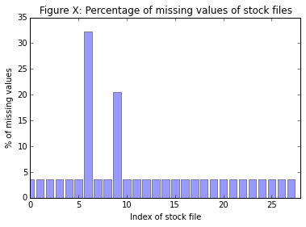

```python
percentageMissingStocks = []
for i,rawStock in enumerate(rawStocks):
    p = percentageMissingValues(rawStock,start,end)
    percentageMissingStocks.append(p)

plt.bar(range(len(percentageMissingStocks)),percentageMissingStocks, alpha=0.4, align="center")
plt.xlabel("Index of stock file")
plt.ylabel("% of missing values")
plt.xlim(0, len(rawStocks))
plt.title("Figure X: Percentage of missing values of stock files")
plt.show()
```

We can clearly see that two stocks don't have 5 years of reccords. Let's try to find out why.

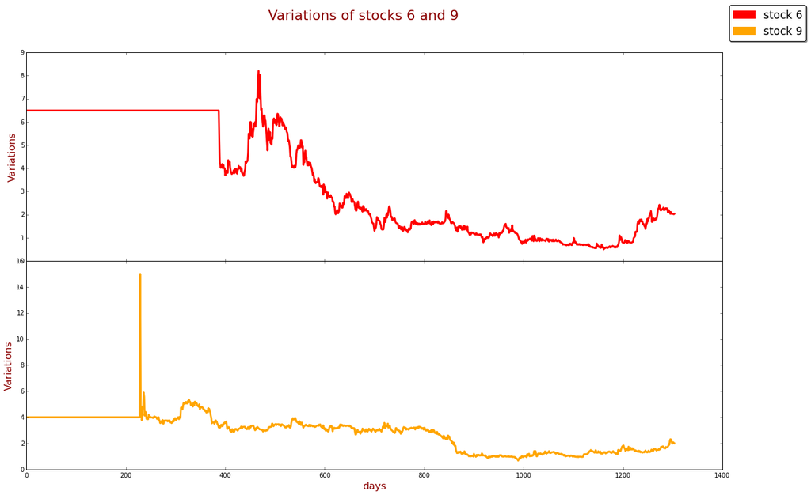

```python
f, (ax1, ax2) = plt.subplots(2, 1, sharex=True)
f.suptitle("Variations of stocks 6 and 9", fontdict=font, fontsize=22)

fig1 = ax1.plot([x[1] for x in fillInHistory(trimToRegion(rawStocks[6],start,end),start,end)],
         lw=3, color="red", label="stock 6")
ax1.set_ylabel("Variations", fontdict=font)
fig2 = ax2.plot([x[1] for x in fillInHistory(trimToRegion(rawStocks[9],start,end),start,end)],
         lw=3, color="orange", label="stock 9")
ax2.set_ylabel("Variations", fontdict=font)
ax2.set_xlabel("days", fontdict=font)
f.subplots_adjust(hspace=0)
patch1 = mpatches.Patch(color='red')
patch2 = mpatches.Patch(color='orange')
f.legend(handles=[patch1, patch2], labels=['stock 6', "stock 9"], fontsize="xx-large", shadow=True, fancybox=True)
f.set_figwidth(20)
f.set_figheight(12)
```

Those missing values comes from the filter function we used before. Taking stocks with more than 5 years of history is not enough since it can be from 2010 to 2015 but not between 2009(start) and 2014(end). We'll change this filter to remove the stocks which are too recent:

```python
# read each line in each file, convert it into the format: (date, value)
rawStocks = [process_stock_file(f) for f in files]

# select only instruments which have more than 5 years of history
# Note: the number of business days in a year is 260
number_of_years = 5
rawStocks = list(filter(lambda instrument: instrument[0][0] <= start and instrument[-1][0] >= end , rawStocks))
```

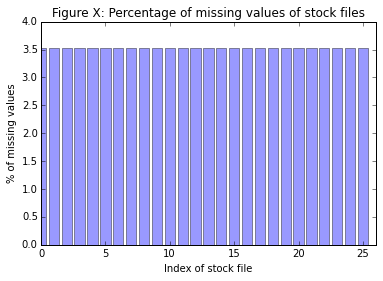

```python
percentageMissingStocks = []
for i,rawStock in enumerate(rawStocks):
    p = percentageMissingValues(rawStock,start,end)
    percentageMissingStocks.append(p)

plt.bar(range(len(percentageMissingStocks)),percentageMissingStocks, alpha=0.4, align="center")
plt.xlabel("Index of stock file")
plt.ylabel("% of missing values")
plt.xlim(0, len(rawStocks))
plt.title("Figure X: Percentage of missing values of stock files")
plt.show()
```

We find quite strange that almost all files have the exact number of missing values over the time region specified, let's see exactly what days are missing for each file, maybe these are the exact same days for all the files.  
Let's see what dates correspond to these missing values.

```python
def getMissingDates(history, start, end):
    curr = [x[0] for x in history]
    missing = []
    idx = 0
    curDate = start
    numEntries = len(history)
    totalDays = 0
    numDaysMissing = 0
    while curDate < end:

        if curDate.weekday() < 5:
            totalDays +=1
            if not curDate in curr:
                missing.append(curDate)
            # move to the next business day
            curDate += timedelta(days=1)

        # skip the weekends
        if curDate.weekday() >= 5:
            # if curDate is Sat, skip 2 days, otherwise, skip 1 day
            curDate += timedelta(days=(7-curDate.weekday()))

    return missing
```

```python
missings = list()
for rawStock in rawStocks:
    missings.append(getMissingDates(rawStock, start, end))
print("All stocks have the same missing dates: ", all([x == missings[0] for x in missings]))
# Let's see the missing values of the first stock in the year 2010
tmp_ =  list(filter(lambda x: x.year==2010, missings[0]))
tmp_ = list(map(lambda x: x.strftime("%D"), tmp_))
print("Stock 0, missing dates for year 2010: \n", tmp_)
```

```
All stocks have the same missing dates:  True
Stock 0, missing dates for year 2010:
 ['01/01/10', '01/18/10', '02/15/10', '04/02/10', '05/31/10', '07/05/10', '09/06/10', '11/25/10', '12/24/10']
```

After some investigation we have discoverd that the missing values are grossly public holidays in the US. See this website (https://archive.opm.gov/operating_status_schedules/fedhol/2010.asp) and the piece of code above to be convinced

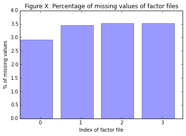

```python
percentageMissingFactors = []
rawFactors = factors1 + factors2
for i,rawFactor in enumerate(rawFactors):
    p = percentageMissingValues(rawFactor,start,end)
    percentageMissingFactors.append(p)

plt.bar(range(len(percentageMissingFactors)),percentageMissingFactors, alpha=0.4)
plt.xlabel("Index of factor file")
plt.ylabel("% of missing values")
plt.title("Figure X: Percentage of missing values of factor files")
plt.xticks([0.5, 1.5, 2.5, 3.5], str("0123"))
plt.xlim(0, 4)
plt.show()
```

About the same amount of missing values than the regular stock files. Again, it is very likely that these missing dates correspond to federal public holidays.

#### Question 4.5

Trim data of stocks and factors into the given time interval.

```
#print rawStocks[0]

# trim into a specific time region
# and fill up the missing values
stocks = list(map(lambda stock: \
            fillInHistory(
                trimToRegion(..., ..., ...),
            start, end),
        rawStocks))



# merge two factors, trim each factor into a time region
# and fill up the missing values
allfactors = factors1 + factors2
factors = list(map(
            ...,
            allfactors
            ))

# test our code
print("the first 5 records of stock 0:", stocks[0][:5], "\n")
print("the last 5 records of stock 0:", stocks[0][-5:], "\n")
print("the first 5 records of factor 0:", factors[0][:5], "\n")
print("the first 5 records of factor 0:", factors[0][-5:], "\n")
```

```python
#print rawStocks[0]

# trim into a specific time region
# and fill up the missing values
stocks = list(map(lambda stock: \
            fillInHistory(
                trimToRegion(stock, start, end),
            start, end),
        rawStocks))



# merge two factors, trim each factor into a time region
# and fill up the missing values
allfactors = factors1 + factors2
factors = list(map(lambda stock: \
            fillInHistory(
                trimToRegion(stock, start, end),
            start, end),
            allfactors
            ))

# test our code
print("the first 5 records of stock 0:", stocks[0][:5], "\n")
print("the last 5 records of stock 0:", stocks[0][-5:], "\n")
print("the first 5 records of factor 0:", factors[0][:5], "\n")
print("the first 5 records of factor 0:", factors[0][-5:], "\n")
```

```
the first 5 records of stock 0: [(datetime.datetime(2009, 1, 23, 0, 0), 7.1), (datetime.datetime(2009, 1, 26, 0, 0), 7.79), (datetime.datetime(2009, 1, 27, 0, 0), 7.73), (datetime.datetime(2009, 1, 28, 0, 0), 7.04), (datetime.datetime(2009, 1, 29, 0, 0), 7.15)]

the last 5 records of stock 0: [(datetime.datetime(2014, 1, 16, 0, 0), 28.940001), (datetime.datetime(2014, 1, 17, 0, 0), 29.299999), (datetime.datetime(2014, 1, 20, 0, 0), 29.299999), (datetime.datetime(2014, 1, 21, 0, 0), 30.66), (datetime.datetime(2014, 1, 22, 0, 0), 30.709999)]

the first 5 records of factor 0: [(datetime.datetime(2009, 1, 23, 0, 0), 46.47), (datetime.datetime(2009, 1, 26, 0, 0), 45.73), (datetime.datetime(2009, 1, 27, 0, 0), 41.58), (datetime.datetime(2009, 1, 28, 0, 0), 42.16), (datetime.datetime(2009, 1, 29, 0, 0), 41.44)]

the first 5 records of factor 0: [(datetime.datetime(2014, 1, 16, 0, 0), 93.96), (datetime.datetime(2014, 1, 17, 0, 0), 94.37), (datetime.datetime(2014, 1, 20, 0, 0), 93.93), (datetime.datetime(2014, 1, 21, 0, 0), 94.99), (datetime.datetime(2014, 1, 22, 0, 0), 96.73)]
```

Recall that Value at Risk (VaR) deals with **losses over a particular time horizon**. We are not concerned with the absolute prices of instruments, but how those prices **change over** a given period of time. In our project, we will set that length to two weeks: we use the sliding window method to transform time series of prices into an overlapping sequence of price change over two-week intervals.

The figure below illustrate this process. The returns of market factors after each two-week intervals is calculated in the very same way.

[figure not shown]

```python
def buildWindow(seq, k=2):
    "Returns a sliding window (of width k) over data from iterable data structures"
    "   s -> (s0,s1,...s[k-1]), (s1,s2,...,sk), ...                   "
    it = iter(seq)
    result = tuple(islice(it, k))
    if len(result) == k:
        yield result
    for elem in it:
        result = result[1:] + (elem,)
        yield result
```

#### Question 4.6

Compute the returns of the stocks after each two week time window.

```
def calculateReturn(window):
    # return the change of value after two weeks
    return ... - ...

def twoWeekReturns(history):
    # we use 10 instead of 14 to define the window
    # because financial data does not include weekends
    return [... for entry in buildWindow(..., 10)]

stocksReturns = list(map(twoWeekReturns, stocks))
factorsReturns = list(map(twoWeekReturns, factors))

# test our functions
print("the first 5 returns of stock 0:", stocksReturns[0][:5])
print("the last 5 returns of stock 0:", stocksReturns[0][-5:])
```

```python
def calculateReturn(window):
    # return the change of value after two weeks
    return window[-1][1] - window[0][1]

def twoWeekReturns(history):
    # we use 10 instead of 14 to define the window
    # because financial data does not include weekends
    return [calculateReturn(entry) for entry in buildWindow(history, 10)]

stocksReturns = list(map(twoWeekReturns, stocks))
factorsReturns = list(map(twoWeekReturns, factors))

# test our functions
print("the first 5 returns of stock 0:", stocksReturns[0][:5])
print("the last 5 returns of stock 0:", stocksReturns[0][-5:])
```

```
the first 5 returns of stock 0: [-1.7199999999999998, -2.3600000000000003, -2.2800000000000002, -1.79, -2.0100000000000007]
the last 5 returns of stock 0: [3.1900009999999988, 2.679998000000001, 2.0999979999999994, 4.289999000000002, 2.4699990000000014]
```

Alright! Now we have data that is properly aligned to start the training process: stocks' returns and factors' returns, per time windows of two weeks. Next, we will apply the MCS method.

## 5.5. Summary guidelines to apply the MCS method on the data we prepared

Next, we overview the steps that you have to follow to build a model of your data, and then use Monte Carlo simulations to produce output distributions:

- **Step 1**: Defining the relationship between the market factors and the instrument's returns. This relationship takes the form of a model fitted to historical data.
- **Step 2**: Defining the distributions for the market conditions (particularly, the returns of factors) that are straightforward to sample from. These distributions are fitted to historical data.
- **Step 3**: Generate the data for each trial of a Monte Carlo run: this amount generates the random values for market conditions along with these distributions.
- **Step 4**: For each trial, from the above values of market conditions, and using the relationship built in step 1, we calculate the return for each instrument and the total return. We use the returns to define an empirical distribution over losses. This means that, if we run 100 trials and want to estimate the 5% VaR, we would choose it as the loss from the trial with the fifth greatest loss.
- **Step 5**: Evaluating the result

## 5.6. Applying MCS

### Step 1: Defining relationship between market factors and instrument's returns

In our simulation, we will use a simple linear model. By our definition of return , a factor return is a **change** in the value of a market factor **over a particular time period**, e.g. if the value of the S&P 500 moves from 2000 to 2100 over a time interval, its return would be 100.

A vector that contains the return of 4 market factors is called a *market factor vector*. Generally, instead of using this vector as features, we derive a set of features from simple transformation of it. In particular, a vector of 4 values is tranformed into a vector of length $m$ by function $F$. In the simplest case $F(v) = v$.

Denote $v_t$ the market factor vector, and $f_t$ the transformed features of $v_t$ at time $t$.

$f_{tj}$ is the value of feature $j$ in $f_t$.

Denote $r_{it}$ the return of instrument $i$ at time $t$ and $c_i$ the [intercept term](http://blog.minitab.com/blog/adventures-in-statistics/regression-analysis-how-to-interpret-the-constant-y-intercept) of instrument $i$.

We will use a simple linear function to calculate $r_{it}$ from $f_t$:

$$ r_{it} = c_i + \sum_{j=1}^{m}{w_{ij}*f_{tj}} $$

where $w_{ij}$ is the weight of feature $j$ for instrument $i$.

All that above means that given a market factor vector, we have to "featurize it" and then use the result as a surrogate for calculating the return of the instruments, using the above linear function.

There are two questions that we should consider: **how to featurize a factor vector ?** and **how to pick values for $w_{ij}$?**

**How to featurize a factor vector ?** In fact, the instruments' returns may be non-linear functions of the factor returns. So, we should not use factor returns as features in the the above linear function. Instead, we tranform them into a set of features with different size. In this Notebook, we can include some additional features in our model that we derive from non-linear transformations of the factor returns. We will try adding two more features for each factor return: its square and its square root values. So, we can still assume that our model is a linear model in the sense that the response variable is a linear function of the new features. *Note that the particular feature transformation described here is meant to be an illustrative example of some of the options that are available: it shouldn't be considered as the state of the art in predictive financial modeling!!*.

**How to pick values for $w_{ij}$ ?**

For all the market factor vectors in our historical data, we tranform them to feature vectors. Now, we have feature vectors in many two-week intervals and the corresponding instrument's returns in these interval. We can use Odinary Least Square (OLS) regression model to estimate the weights for each instrument such that our linear function can fit to the data. The parameters for OLS function are:

- `x`: The collection of columns where **each column** is the value of **a feature** in many two-week interval
- `y`: The return of an instrument in the corresponding time interval of x.

The figure below shows the basic idea of the process to build a statistial model for predicting the returns of stock X.

[figure not shown]

### Question 5

#### Question 5.1

Currently, our data is in form of:

$$ factorsReturns= \begin{bmatrix} r_{00} & r_{01} & r_{02} & ... & r_{0k} \\ r_{10} & r_{11} & r_{12} & ... & r_{1k} \\ ... & ... & ... & ... & ... \\ r_{n0} & r_{n1} & r_{n2} & ... & r_{nk}\\ \end{bmatrix} $$$$ stocksReturns= \begin{bmatrix} s_{00} & s_{01} & s_{02} & ... & s_{0k} \\ s_{10} & s_{11} & s_{12} & ... & s_{1k} \\ ... & ... & ... & ... & ... \\ s_{n0} & s_{n1} & s_{n2} & ... & s_{nk}\\ \end{bmatrix} $$

Where, $r_{ij}$ is the return of factor $i^{th}$ in time window $j^{th}$, $k$ is the number of time windows, and $n$ is the number of factors. A similar definition goes for $s_{ij}$.

In order to use OLS, the parameter must be in form of:

$$ x=factorsReturns^T = \begin{bmatrix} r_{00} & r_{10} & ... & r_{n0} \\ r_{01} & r_{11} & ... & r_{n1} \\ r_{02} & r_{12} & ... & r_{n2}\\ ... & ... & ... & ... \\ r_{0k} & r_{1k} & ... & r_{nk}\\ \end{bmatrix} $$

Whereas, $y$ can be any row in `stocksReturns`.

So, we need a function to transpose a matrix. Write a function named `transpose` to do just that.

```
def transpose(matrix):
    ...
    return ...

# test function
assert (transpose([[1,2,3], [4,5,6], [7,8,9]]) == [[1, 4, 7], [2, 5, 8], [3, 6, 9]]), "Function transpose runs incorrectly"
```

```python
def transpose(matrix):
    return [[matrix[j][i] for j in range(len(matrix))] for i in range(len(matrix[0]))]

# test function
assert (transpose([[1,2,3], [4,5,6], [7,8,9]]) == [[1, 4, 7], [2, 5, 8], [3, 6, 9]]), "Function transpose runs incorrectly"
```

#### Question 5.2

Write a function named `featurize` that takes a list factor's returns $[x_1, x_2,...,x_k]$ and transform it into a new list of features $[u_1,u_2,..,u_k, v_1, v_2,..,v_k, x_1,x_2,...,x_k]$.

Where

$u_i$ = $\left\{ \begin{array}{ll} x_i^2 & \mbox{if } x_i \geq 0 \\ -x_i^2 & \mbox{if } x_i < 0 \end{array} \right. $

and

$v_i$ = $\left\{ \begin{array}{ll} \sqrt{x_i} & \mbox{if } x_i \geq 0 \\ -\sqrt{x_i} & \mbox{if } x_i < 0 \end{array} \right. $

```
def featurize(factorReturns):
    squaredReturns = [...]
    squareRootedReturns = [...]
    # concat new features
    return ... + ... + ...

# test our function
assert (featurize([4, -9, 25]) == [16, -81, 625, 2, -3, 5, 4, -9, 25]), "Function runs incorrectly"
```

```python
def sign(number):
    if number<0:
        return -1
    else:
        return 1

def featurize(factorReturns):
    factorReturns = list(factorReturns)
    squaredReturns = [sign(element)*(element)**2 for element in factorReturns]
    squareRootedReturns = [sign(element)*abs(element)**0.5 for element in factorReturns]
    # concat new features
    return squaredReturns + squareRootedReturns + factorReturns

# test our function
assert (featurize([4, -9, 25]) == [16, -81, 625, 2, -3, 5, 4, -9, 25]), "Function runs incorrectly"
```

#### Question 5.3

Using OLS, estimate the weights for each feature on each stock. What is the shape of `weights` (size of each dimension) ? Explain it.

```
def estimateParams(y, x):
    return sm.OLS(y, x).fit().params

# transpose factorsReturns
factorMat = ...

# featurize each row of factorMat
factorFeatures = list(map(...,...))

# OLS require parameter is a numpy array
factor_columns = np.array(factorFeatures)

#add a constant - the intercept term for each instrument i.
factor_columns = sm.add_constant(factor_columns, prepend=True)

# estimate weights
weights = [... for stockReturns in stocksReturns]

print("weights:", weights)
```

```python
def estimateParams(y, x, isOnNode = False):
    if isOnNode:
        assert False
        x=transpose(x)
        x.pop(0)
        X = np.column_stack(x+[[1]*len(x[0])])
        beta_hat = np.linalg.lstsq(X,y)[0]
        return beta_hat
    else:
        return sm.OLS(y, x).fit().params

# transpose factorsReturns
factorMat = transpose(factorsReturns)

# featurize each row of factorMat
factorFeatures = list(map(featurize,factorMat))

# OLS require parameter to be a numpy array
factor_columns = np.array(factorFeatures)

# add a constant - the intercept term for each instrument i.
factor_columns = sm.add_constant(factor_columns, prepend=True)

# estimate weights
weights = [estimateParams(stockReturns, factor_columns) for stockReturns in stocksReturns]
print("weights:", weights)
```

```
weights: [array([  6.86741405e-02,  -1.93208835e-03,   8.39012843e-01,
        -5.17217915e-05,   1.48377526e-05,   5.82141478e-02,
         3.87772837e-01,  -5.97560383e-02,   3.83232849e-02,
        -6.28107422e-02,  -1.77435081e+00,   1.26641313e-02,
         4.52797635e-05]), array([  1.87799850e-02,  -1.37778284e-04,   1.01069390e-01,
         3.60466101e-06,   5.31258980e-07,  -2.05067861e-02,
        -2.68937261e-02,   9.70736871e-04,   2.32274331e-03,
         8.51623110e-03,   4.71136605e-02,  -6.18256895e-05,
        -1.43902760e-04]), array([ -4.90849991e-02,   3.63974080e-03,   2.57467254e+00,
         6.64078939e-05,  -2.48222073e-05,   2.19767820e-01,
        -5.79162192e-01,  -6.53711434e-03,  -1.36491064e-02,
        -1.08299858e-01,   1.17773327e+00,   1.33410271e-03,
         1.04695235e-02]), array([ -2.42056870e-02,   3.02596533e-02,  -8.62109463e+00,
         9.70294760e-04,  -1.64661324e-04,   1.68380383e+00,
         5.12889988e+00,   5.59623903e-01,   2.13974882e-01,
        -7.26077465e-01,  -1.69612952e+01,  -5.06514640e-01,
         2.91123024e-01]), array([ -3.47627944e-01,   1.82624164e-02,   2.02009493e+00,
        -5.89122319e-05,  -3.34895350e-05,   4.16573906e-01,
        -2.84028192e+00,  -1.26158655e-01,   8.03006636e-02,
        -2.87883117e-01,   7.27016598e+00,   3.28042286e-02,
         1.94432892e-02]), array([ -1.16284182e-01,  -1.38686011e-02,   2.29101313e+00,
        -4.73244934e-05,   8.83783206e-06,  -3.86411712e-01,
        -1.53488735e-01,  -7.60605530e-02,   3.02874174e-02,
         3.44546645e-01,   9.57048740e-01,   3.32855560e-02,
         3.91451975e-03]), array([  6.04250282e-02,   3.63282573e-03,   1.09476437e+01,
         4.83209840e-05,  -5.90651213e-06,   3.19305510e-01,
        -1.54650087e-01,   1.13002935e-02,   1.05790762e-03,
        -9.43103742e-02,  -2.41804949e+00,   1.13746077e-02,
         1.22567877e-03]), array([  1.37144070e-02,  -5.01711173e-04,   2.26846315e-01,
         3.65714860e-05,  -1.61553551e-05,  -7.07223967e-02,
         2.62417747e-01,  -1.26326642e-02,  -4.14802963e-03,
         3.24357551e-02,  -6.53635566e-01,   3.88667731e-03,
         4.78115638e-03]), array([  1.25807120e-01,  -4.44696920e-02,   5.25784639e+00,
        -1.54202362e-04,   4.19417272e-05,  -4.82589102e-01,
         2.54820024e+00,   1.16667877e-01,  -1.10259532e-01,
         5.73695749e-01,  -7.62761713e+00,   2.19420839e-03,
         6.77605214e-03]), array([ -3.80066686e-02,   5.90207890e-03,  -4.09522680e+00,
         2.77107253e-05,   4.16109709e-06,   1.75030729e-01,
        -6.71651161e-01,   4.09742799e-02,   1.89094816e-02,
        -1.31533523e-01,   2.76940852e+00,  -2.84401088e-03,
```

[output cut: 50 more lines]

```
        -5.24475925e-02,   5.59102221e-03,   5.48042573e-04,
         9.55562610e-04,   2.15097595e-01,  -1.22066202e-03,
         1.08139137e-03]), array([  4.55043297e-02,  -4.02970730e-03,   1.09015234e+00,
        -1.45159744e-05,   9.71332110e-06,  -8.75918787e-02,
         2.99200097e-01,  -1.11076735e-03,   1.20925627e-02,
         6.16111021e-02,  -6.46469497e-01,   2.54708520e-03,
        -2.36321270e-03]), array([ -4.55359541e-02,   5.24813005e-03,   2.32920329e+00,
        -9.74710060e-05,  -1.66392996e-05,   1.31604957e-01,
        -1.37742164e+00,  -2.17024763e-01,   7.95737948e-03,
        -1.67070822e-02,   2.43692538e+00,   4.85329013e-02,
         2.72619942e-03]), array([  1.04738430e-02,   6.32831150e-04,   9.58446458e-01,
         1.56128324e-05,   4.02844841e-06,   6.31705874e-02,
         2.06091390e-01,   1.46151979e-02,   8.74040557e-03,
        -2.57322830e-02,  -6.08044545e-01,  -3.22483804e-03,
        -9.22349586e-04])]
```

We tried to fit a model on some data. The obvious question here is to check the mean square error to see if our model should be changed.

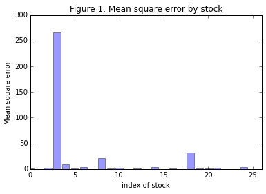

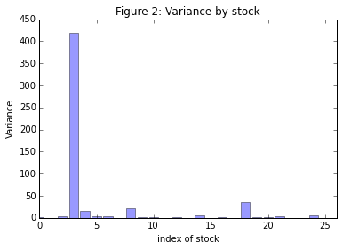

```python
def mean_square(computedValues, realValues):
    zipped = list(zip(computedValues, realValues))
    squares = [(x[0] - x[1])**2 for x in zipped]
    return sum(squares)/len(squares)

def predict(feat, weights):
    l = [feat[i]*weights[i] for i in range(len(feat))]
    return sum(l)

listOfMeanSquares = []
listOfVariances = []

for i in range(len(weights)):

    predictions = map(lambda feat: predict(feat, weights[i]), factor_columns)
    meanError = mean_square(predictions, stocksReturns[i])
    listOfMeanSquares.append(meanError)
    varianceSquare = np.std(stocksReturns[i])**2
    listOfVariances.append(varianceSquare)

plt.bar(range(len(listOfMeanSquares)), listOfMeanSquares, alpha=0.4, align="center")
plt.title("Figure 1: Mean square error by stock")
plt.xlabel("index of stock")
plt.ylabel("Mean square error")
plt.xlim(0, len(listOfMeanSquares))
plt.show()
plt.bar(range(len(listOfVariances)), listOfVariances, alpha=0.4, align="center")
plt.title("Figure 2: Variance by stock")
plt.xlabel("index of stock")
plt.ylabel("Variance")
plt.xlim(0, len(listOfVariances))
plt.show()
```

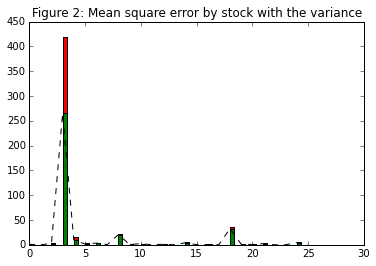

```python
thresholds = np.array(listOfMeanSquares)
values = np.array(listOfVariances)
x = range(len(values))

# split it up
above_threshold = np.maximum(values - thresholds, 0)
below_threshold = np.minimum(values, thresholds)
# and plot it
fig, ax = plt.subplots()
ax.bar(x, below_threshold, 0.35, color="g")
ax.bar(x, above_threshold, 0.35, color="r",
        bottom=below_threshold)

plt.title("Figure 2: Mean square error by stock with the variance")

# horizontal line indicating the threshold
ax.plot(x, thresholds, "k--")
```

```python
# handy function , parameter is just an index
def plotPredictionsVSReals(nStock):
    predictions = map(lambda x: predict(x, weights[nStock]),factor_columns)
    plt.figure(figsize=(20,10))
    plt.plot(list(predictions), lw=2)
    plt.plot(stocksReturns[nStock], lw=2)
    plt.legend(["predictions", "real"], fontsize="xx-large")
    plt.xlabel("2 weeks window", fontdict=font)
    plt.ylabel("variation over the window", fontdict=font)
    plt.title("Predictions vs Real Stock n{}".format(nStock), fontdict=font)
    plt.xlim(0, len(stocksReturns[nStock]))
    plt.show()
```

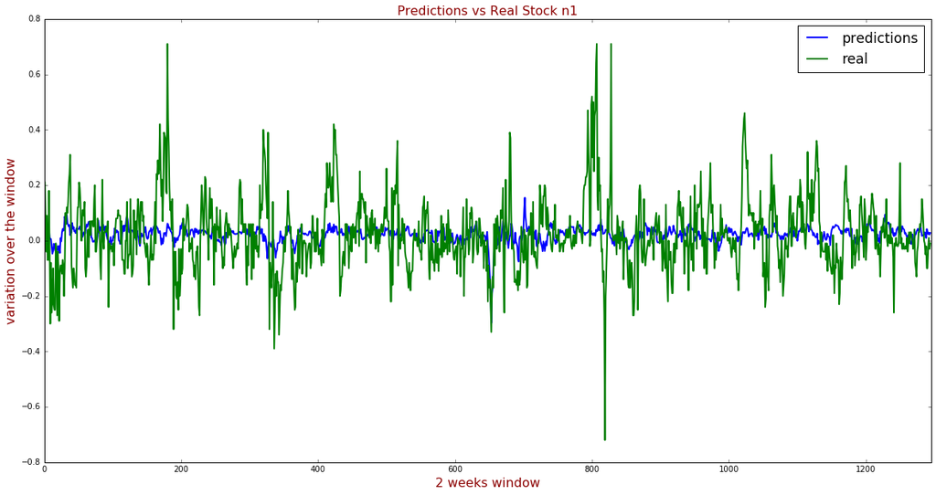

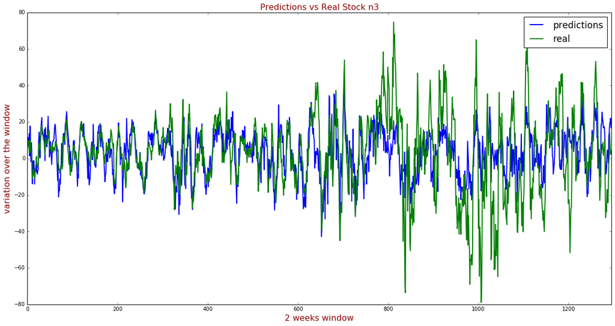

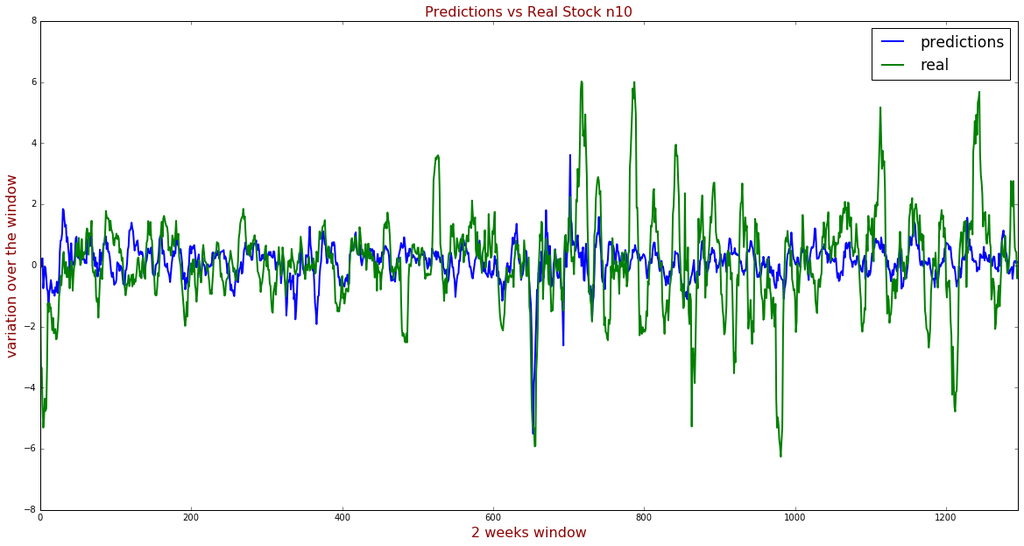

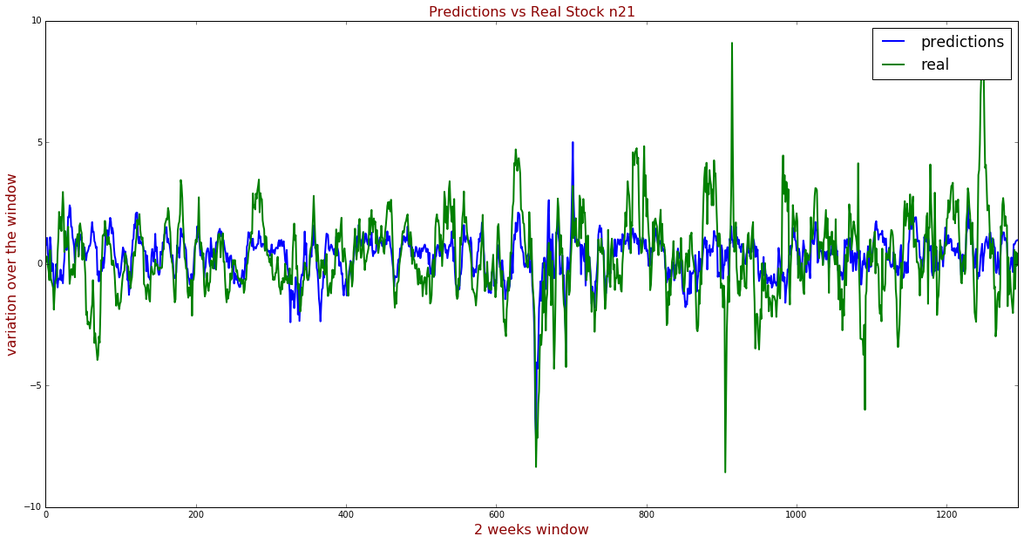

```python
plotPredictionsVSReals(1)
plotPredictionsVSReals(3)
plotPredictionsVSReals(10)
plotPredictionsVSReals(21)
```

Actually it is not a good idea to compare the mean square errors of the different stocks with one given model. The stocks that have a much high MSE have actually a wider range of variation, the amplitude of the variations are much more important and therefore the MSE is higher. MSE will be an crucial criteria when it will come to compare this first linear model with other models, but not to compare how well one model perform on different stocks.

What we see here is that our model cannot take extreme values. We're far from overfitting in this case. Maybe for this kind of stocks, we should add more features (x\*\*3,x\*\*4...). It's still encouraging because our model does a pretty good job at the beginning.

### Step 2: Defining the distributions for the market conditions

Since we can not define the ditributions for the market factors directly, we can only approximate their distribution. The best way to do that, is plotting their value. Howevery, these values may fluctuate quite a lot.

Next, we show how to use the Kernel density estimation (KDE) technique to approximate such distributions. In brief, kernel density estimation is a way of smoothing out a histogram: this is achieved by assigning (or centering) a probability distribution (usually a normal distribution) to each data point, and then summing. So a set of two-week-return samples would result in a large number of "super-imposed" normal distributions, each with a different mean.

To estimate the probability density at a given point, KDE evaluates the PDFs of all the normal distributions at that point and takes their average. The smoothness of a kernel density plot depends on its *bandwidth*, and the standard deviation of each of the normal distributions. For a brief introduction on KDE, please refer to this [link](https://en.wikipedia.org/wiki/Kernel_density_estimation).

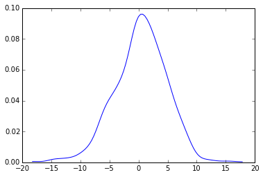

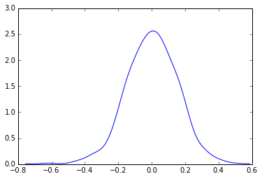

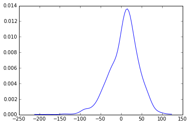

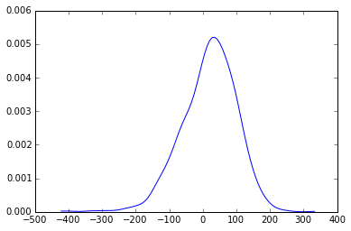

```python
from statsmodels.nonparametric.kernel_density import KDEMultivariate
from statsmodels.nonparametric.kde import KDEUnivariate
import matplotlib.pyplot as plt
import scipy

def plotDistribution(samples, plot=True, numSamples=100):
    vmin = min(samples)
    vmax = max(samples)
    stddev = np.std(samples)

    domain = np.arange(vmin, vmax, (vmax-vmin)/numSamples)

    # a simple heuristic to select bandwidth
    bandwidth = 1.06 * stddev * pow(len(samples), -.2)

    # estimate density
    kde = KDEUnivariate(samples)
    kde.fit(bw=bandwidth)
    density = kde.evaluate(domain)

    # plot
    # We do a little change because later we will use the data but plot it after
    if(plot):
        plt.plot(domain, density)
        plt.show()
    else:
        return domain,density

plotDistribution(factorsReturns[0])
plotDistribution(factorsReturns[1])
plotDistribution(factorsReturns[2])
plotDistribution(factorsReturns[3])
```

For the sake of simplicity, we can say that our smoothed versions of the returns of each factor can be represented quite well by a a normal distribution. Of course, more exotic distributions, perhaps with fatter tails, could fit more closely the data, but it is outside the scope of this Notebook to proceed in this way.

Now, the simplest way to sample factors returns is to use a normal distribution for each of the factors, and sample from these distributions independently. However, this approach ignores the fact that market factors are often correlated. For example, when the price of crude oil is down, the price of treasury bonds is down too. We can check our data to verify about the correlation.

[figure not shown]